# Fortgeschrittene Lineare Algebra und Analytische Geometrie

Übungsaufgaben

Martin Zaefferer

# 1 Anmerkungen

## 1.1 Krumme Zahlen

Im Folgenden muss ab und an mit Wurzeln und Brüchen gerechnet werden. Sie können gerne die Lösungen bei *‘krummen’* Zahlen weiter als Wurzeln angeben und müssen keine reellen Zahlen ausrechnen (z.B reicht $\sqrt{2}/2$ statt $0.7071068$, bzw. reicht $1/7$ statt $0.1428571$). Beachten Sie aber, dass die Lösungsvorschläge der Einfachheit halber Kommazahlen verwenden. ‘Glatte’ Wurzeln wie $\sqrt{4}, \sqrt{9}, \sqrt{16}$ sollten Sie aber ausrechnen können, auch ohne Taschenrechner.

## 1.2 Weitere Übungsaufgaben

Für weitere Übungen sind die entsprechenden Aufgaben aus den Buchquellen von Interesse:

- Strang. 2020. Linear Algebra for Everyone. Wellesley-Cambridge Press.
  - Scan von Übungsaufgaben liegt im Moodle
- Deisenroth, Faisal, Ong. 2021. Mathematics for Machine Learning. Cambridge University Press
  - Enthält Übungsaufgaben

# 2 Symbolisches Rechnen

Es folgen einige Aufgaben die einerseits Grundlagen der Themen betreffen, andererseits mit Hilfe der in den vorigen Abschnitten genutzten Zusammenhänge gelöst werden können.

## 2.1 Aufgabe

Zeigen Sie, dass die Inverse einer symmetrischen $n \times n$ Matrix auch symmetrisch ist.

Es gibt mehrere Möglichkeiten. z.B. unter Anwendung der Regel $(A^{-1})^T=(A^T)^{-1}$. Oder auch mit der Spektralzerlegung.

Click zum Öffnen, Click auf Inhalt zum Schließen.

## 2.2 Aufgabe

Vereinfachen Sie folgenden Term soweit wie möglich. (Annahme: Inverse existiert und die Matrix ist quadratisch)

$$\left|\left(\left(\left(\left(A^T\right)^{-1}\right)^T\right)^2\right)^T\right|$$

Click zum Öffnen, Click auf Inhalt zum Schließen.

## 2.3 Aufgabe

Vereinfachen Sie folgenden Term soweit wie möglich. (Annahme: Inverse existiert und die Matrix ist quadratisch)

$$\left|\left(\left(A^{-1}B\right)^T
A^T\right)^{-1}\right|$$

Click zum Öffnen, Click auf Inhalt zum Schließen.

## 2.4 Aufgabe

Welche der folgenden Gleichungen ist richtig, für alle quadratischen Matrizen $A,B$?

1. $AB = BA$
2. $(AB)A = A(BA)$
3. $(AB)B = B(BA)$
4. $(AB)^2 = A^2B^2$

Click zum Öffnen, Click auf Inhalt zum Schließen.

## 2.5 Aufgabe

Zeigen Sie, dass $A=B+B^T$ für quadratische Matrizen symmetrisch ist.

Click zum Öffnen, Click auf Inhalt zum Schließen.

# 3 A=CR

## 3.1 Aufgabe

Geben Sie für die Matrix $A$ eine Basis des Spaltenraumes an.

$A=$ $\begin{pmatrix} 1 & 1 & 1 \\ 1 & 1 & 1 \\ 1 & 1 & 1 \\ 1 & 1 & 1 \\ 1 & 1 & 1 \\ \end{pmatrix}$

Click zum Öffnen, Click auf Inhalt zum Schließen.

## 3.2 Aufgabe

Geben Sie für die Matrix $A$ eine Basis des Spaltenraumes an.

$A=$ $\begin{pmatrix} 1.0 & -2.1 & 3.3 & 1.7 \\ 2.0 & -4.2 & 6.6 & 3.4 \\ 3.0 & -6.3 & 9.9 & 5.1 \\ 4.0 & -8.4 & 13.2 & 6.8 \\ 5.0 & -10.5 & 16.5 & 8.5 \\ \end{pmatrix}$

Click zum Öffnen, Click auf Inhalt zum Schließen.

## 3.3 Aufgabe

Geben Sie für die Matrix $A$ eine Basis des Spaltenraumes an.

$A=$ $\begin{pmatrix} 6 & 1 & 5 \\ 6 & 2 & 4 \\ 6 & 3 & 3 \\ 6 & 4 & 2 \\ 6 & 5 & 1 \\ \end{pmatrix}$

Click zum Öffnen, Click auf Inhalt zum Schließen.

## 3.4 Aufgabe

Geben Sie für die Matrix $A$ eine Basis des Spaltenraumes an.

$A=$ $\begin{pmatrix} 0 & 1 & 0 & 0 & 0 \\ 0 & 0 & 0 & 1 & 0 \\ 1 & 0 & 1 & 1 & 0 \\ 1 & 0 & 0 & 1 & 1 \\ 1 & 1 & 0 & 1 & 0 \\ \end{pmatrix}$

Click zum Öffnen, Click auf Inhalt zum Schließen.

## 3.5 Aufgabe

Geben Sie für die Matrix $A$ die zugehörige Matrix $C$ der unabhängigen Spalten an, für die Zerlegung $A=CR$. Hierzu ist auch bereits die Matrix $R$ gegeben.

$A=$ $\begin{pmatrix} -2 & -2 & 2 & -1 & -2 \\ 0 & 1 & -2 & -1 & -2 \\ 0 & -2 & -2 & 2 & -2 \\ \end{pmatrix}$  
$R=$ $\begin{pmatrix} 1.0 & 0.0 & 0.0 & 1.5 & 2.0 \\ 0.0 & 1.0 & 0.0 & -1.0 & 0.0 \\ 0.0 & 0.0 & 1.0 & 0.0 & 1.0 \\ \end{pmatrix}$

Click zum Öffnen, Click auf Inhalt zum Schließen.

## 3.6 Aufgabe

Geben Sie für die Matrix $A$ die zugehörige Matrix $C$ der unabhängigen Spalten an, für die Zerlegung $A=CR$. Hierzu ist auch bereits die Matrix $R$ gegeben.

$A=$ $\begin{pmatrix} 2 & 1 & 1 & 2 & 1 & 2 \\ 1 & 2 & 2 & 2 & 1 & 1 \\ 1 & 1 & 1 & 2 & 1 & 2 \\ 1 & 2 & 2 & 2 & 1 & 1 \\ \end{pmatrix}$  
$R=$ $\begin{pmatrix} 1.0 & 0.0 & 0.0 & 0.0 & 0.0 & 0.0 \\ 0.0 & 1.0 & 1.0 & 0.0 & 0.0 & -1.0 \\ 0.0 & 0.0 & 0.0 & 1.0 & 0.5 & 1.5 \\ \end{pmatrix}$

Click zum Öffnen, Click auf Inhalt zum Schließen.

## 3.7 Aufgabe

Geben Sie für die Matrix $A$ die zugehörigen Matrizen $C$ und $R$ an, für die Zerlegung $A=CR$.

$A=$ $\begin{pmatrix} 2 & 2 & 2 & 0 \\ 2 & 2 & 1 & 1 \\ \end{pmatrix}$

Click zum Öffnen, Click auf Inhalt zum Schließen.

## 3.8 Aufgabe

Zeigen Sie, dass die folgende Matrix $A$ als Multiplikation zweier Vektoren dargestellt werden kann.

$A=$ $\begin{pmatrix} 8 & 16 & -8 & -16 \\ 3 & 6 & -3 & -6 \\ 3 & 6 & -3 & -6 \\ 7 & 14 & -7 & -14 \\ \end{pmatrix}$

Click zum Öffnen, Click auf Inhalt zum Schließen.

## 3.9 Aufgabe

Gegeben ist die Matrix

$A=$ $\begin{pmatrix} 1 & 2 & 0 & 1 \\ 0 & 0 & 1 & 1 \\ \end{pmatrix}$

Zeigen Sie für diese Matrix, dass der Zeilenraum $R(A)=C(A^T)$ orthogonal zum Nullraum $N(A)$ steht.

Click zum Öffnen, Click auf Inhalt zum Schließen.

Click zum Öffnen, Click auf Inhalt zum Schließen.

## 3.10 Aufgabe

Gegeben ist die Matrix

$A=$ $\begin{pmatrix} -2 & 2 & 2 & -2 \\ 0 & 2 & 2 & 1 \\ 0 & 1 & 2 & 2 \\ \end{pmatrix}$

Zeigen Sie für diese Matrix, dass der Spaltenraum $C(A)$ orthogonal zum Nullraum $N(A^T)$ steht.

Click zum Öffnen, Click auf Inhalt zum Schließen.

Click zum Öffnen, Click auf Inhalt zum Schließen.

## 3.11 Aufgabe

Für eine beliebige Matrix $A$, was können wir über eine mögliche Orthogonalität von den beiden Nullräumen $N(A), N(A^T)$ sagen?

Click zum Öffnen, Click auf Inhalt zum Schließen.

## 3.12 Aufgabe

Für eine quadratische Matrix $A$ mit vollem Rang, was können wir über den Zusammenhang der Nullräumen $N(A), N(A^T)$ sagen?

Click zum Öffnen, Click auf Inhalt zum Schließen.

## 3.13 Aufgabe

Bestimmen Sie die Magic Factorization der Matrix $A=$

$\begin{pmatrix} 1 & 2 & 2 & 1 & 2 \\ 2 & 4 & 1 & 2 & 4 \\ \end{pmatrix}$

Click zum Öffnen, Click auf Inhalt zum Schließen.

## 3.14 Aufgabe

Bestimmen Sie die Magic Factorization der Matrix $A=$

$\begin{pmatrix} 1 & 2 & 2 & 1 & 2 \\ 2 & 4 & 1 & 2 & 4 \\ 1 & 2 & 1 & 1 & 2 \\ \end{pmatrix}$

Click zum Öffnen, Click auf Inhalt zum Schließen.

## 3.15 Aufgabe

Wenn eine $7 \times 9$ Matrix den Rang 5 hat, welche Dimension haben jeweils die vier Untervektorräume (Zeilenraum, Spaltenraum, zugehörige Nullräume)?

Click zum Öffnen, Click auf Inhalt zum Schließen.

## 3.16 Aufgabe

Erzeugen Sie eine Matrix mit folgenden Eigenschaften oder begründen Sie, warum das nicht möglich ist:

1. Dimension von $N(A)$ ist gleich Dimension von $N(A^T)$ plus Eins.

Click zum Öffnen, Click auf Inhalt zum Schließen.

2. Spaltenraum enthält $\vec v_1=\pmatrix{1\\1\\0}$ und $\vec v_2=\pmatrix{0\\0\\1}$, Zeilenraum enthält $\vec v_3=\pmatrix{1\\2}$ und $\vec v_4= \pmatrix{2\\5}$

Click zum Öffnen, Click auf Inhalt zum Schließen.

3. Spaltenraum hat Basis $\pmatrix{1\\1\\3}$ und Nullraum hat Basis $\pmatrix{3\\1\\1}$.

Click zum Öffnen, Click auf Inhalt zum Schließen.

## 3.17 Aufgabe

Bestimmen Sie ohne Gaussumformungen die Dimension und Basen der vier üblichen Unterräume, jeweils unabhängig für

$A=\pmatrix{0&3&3&3\\0&0&0&0\\0&1&0&1}$ und $B=\pmatrix{1\\4\\5}$

Click zum Öffnen, Click auf Inhalt zum Schließen.

## 3.18 Aufgabe

Gegeben ist $\vec v=\pmatrix{1,2,3}$. Kann $\vec v$ gleichzeitig eine Zeile einer Matrix $A$ darstellen UND auch im Nullraum dieser Matrix $A$ liegen? Warum bzw. warum nicht?

Click zum Öffnen, Click auf Inhalt zum Schließen.

## 3.19 Aufgabe

Teil 1:

$A^T\vec y =\vec d$ ist lösbar, wenn $\vec d$ in welchem der 4 Unterräume von $A$ liegt?

Click zum Öffnen, Click auf Inhalt zum Schließen.

Teil 2:

Die Lösung $\vec y$ von $A^T\vec y =\vec d$ ist einzigartig, wenn ____ nur den Nullvektor enthält?

Click zum Öffnen, Click auf Inhalt zum Schließen.

# 4 A=LU etc

## 4.1 Aufgabe

Gegeben ist für die Matrix $A$ die zugehörige Zerlegung $A=LU$. Lösen Sie mit dieser Zerlegung das Gleichungssystem $A\vec x = \vec b$. Prüfen Sie die Lösung geeignet mit $A$.

$A=$ $\begin{pmatrix} 1 & 1 & 1 \\ 2 & 5 & 5 \\ 3 & 12 & 14 \\ \end{pmatrix}$  
$b=$ $\begin{pmatrix} 1 \\ 3 \\ 6 \\ \end{pmatrix}$  
$L=$ $\begin{pmatrix} 1 & 0 & 0 \\ 2 & 1 & 0 \\ 3 & 3 & 1 \\ \end{pmatrix}$  
$U=$ $\begin{pmatrix} 1 & 1 & 1 \\ 0 & 3 & 3 \\ 0 & 0 & 2 \\ \end{pmatrix}$

Click zum Öffnen, Click auf Inhalt zum Schließen.

## 4.2 Aufgabe

Gegeben ist für die Matrix $A$ die zugehörige Zerlegung $A=LU$. Lösen Sie mit dieser Zerlegung das Gleichungssystem $A\vec x = \vec b$. Prüfen Sie die Lösung geeignet mit $A$.

$A=$ $\begin{pmatrix} 2 & 1 & 1 \\ 2 & 4 & 4 \\ 4 & 8 & 12 \\ \end{pmatrix}$  
$b=$ $\begin{pmatrix} 4 \\ 6 \\ 1 \\ \end{pmatrix}$  
$L=$ $\begin{pmatrix} 1 & 0 & 0 \\ 1 & 1 & 0 \\ 2 & 2 & 1 \\ \end{pmatrix}$  
$U=$ $\begin{pmatrix} 2 & 1 & 1 \\ 0 & 3 & 3 \\ 0 & 0 & 4 \\ \end{pmatrix}$

Click zum Öffnen, Click auf Inhalt zum Schließen.

## 4.3 Aufgabe

Gegeben ist für die Matrix $A$ die zugehörige Zerlegung $A=LU$. Lösen Sie mit dieser Zerlegung das Gleichungssystem $A\vec x = \vec b$. Prüfen Sie die Lösung geeignet mit $A$.

$A=$ $\begin{pmatrix} 1 & 7 & 7 \\ 8 & 59 & 61 \\ 4 & 40 & 50 \\ \end{pmatrix}$  
$b=$ $\begin{pmatrix} 1 \\ 8 \\ 3 \\ \end{pmatrix}$  
$L=$ $\begin{pmatrix} 1 & 0 & 0 \\ 8 & 1 & 0 \\ 4 & 4 & 1 \\ \end{pmatrix}$  
$U=$ $\begin{pmatrix} 1 & 7 & 7 \\ 0 & 3 & 5 \\ 0 & 0 & 2 \\ \end{pmatrix}$

Click zum Öffnen, Click auf Inhalt zum Schließen.

## 4.4 Aufgabe

Gegeben ist für die Matrix $A$ die zugehörige Zerlegung $A=LU$. Lösen Sie mit dieser Zerlegung das Gleichungssystem $A\vec x = \vec b$. Prüfen Sie die Lösung geeignet mit $A$.

$A=$ $\begin{pmatrix} 1 & 1 & 1 & 1 \\ -1 & -2 & -2 & -2 \\ 1 & 0 & 1 & -1 \\ -1 & 0 & -1 & 0 \\ \end{pmatrix}$  
$b=$ $\begin{pmatrix} 4 \\ 2 \\ 3 \\ 5 \\ \end{pmatrix}$  
$L=$ $\begin{pmatrix} 1 & 0 & 0 & 0 \\ -1 & 1 & 0 & 0 \\ 1 & 1 & 1 & 0 \\ -1 & -1 & -1 & 1 \\ \end{pmatrix}$  
$U=$ $\begin{pmatrix} 1 & 1 & 1 & 1 \\ 0 & -1 & -1 & -1 \\ 0 & 0 & 1 & -1 \\ 0 & 0 & 0 & -1 \\ \end{pmatrix}$

Click zum Öffnen, Click auf Inhalt zum Schließen.

## 4.5 Aufgabe

Gegeben ist für die Matrix $A$ die zugehörige Zerlegung $A=LU$. Lösen Sie mit dieser Zerlegung das Gleichungssystem $A\vec x = \vec b$.

$A=$ $\begin{pmatrix} 2 & 1 \\ 4 & 2 \\ \end{pmatrix}$  
$b=$ $\begin{pmatrix} 4 \\ 8 \\ \end{pmatrix}$  
$L=$ $\begin{pmatrix} 1 & 0 \\ 2 & 1 \\ \end{pmatrix}$  
$U=$ $\begin{pmatrix} 2 & 1 \\ 0 & 0 \\ \end{pmatrix}$

Click zum Öffnen, Click auf Inhalt zum Schließen.

## 4.6 Aufgabe

Gegeben ist die Matrix $A$. Bestimmen Sie die zugehörige Zerlegung $A=LU$. Lösen Sie **mit dieser Zerlegung** das Gleichungssystem $A\vec x = \vec b$.

$A=$ $\begin{pmatrix} 2 & 1 \\ 4 & 2 \\ \end{pmatrix}$  
$b=$ $\begin{pmatrix} 4 \\ 8 \\ \end{pmatrix}$

Click zum Öffnen, Click auf Inhalt zum Schließen.

## 4.7 Aufgabe

Gegeben ist die Matrix $A$. Bestimmen Sie die zugehörige Zerlegung $A=LU$. Lösen Sie **mit dieser Zerlegung** das Gleichungssystem $A\vec x = \vec b$.

$A=$ $\begin{pmatrix} 1 & 0 & 2 \\ 0 & 2 & 0 \\ 2 & 0 & 4 \\ \end{pmatrix}$  
$b=$ $\begin{pmatrix} 4 \\ 8 \\ 4 \\ \end{pmatrix}$

Click zum Öffnen, Click auf Inhalt zum Schließen.

## 4.8 Aufgabe

Für welchen Vektor der rechten Seite $\vec b$ hätte sich in der vorigen Aufgabe eine nicht-leere Lösungsmenge ergeben?

Click zum Öffnen, Click auf Inhalt zum Schließen.

## 4.9 Aufgabe

Gegeben ist die Matrix $A$. Bestimmen Sie die zugehörige Zerlegung $A=LU$ mittels ZSF.

$A=$ $\begin{pmatrix} 3 & 1 \\ -6 & -4 \\ \end{pmatrix}$

Click zum Öffnen, Click auf Inhalt zum Schließen.

## 4.10 Aufgabe

Gegeben ist die Matrix $A$. Bestimmen Sie die zugehörige Zerlegung $A=LU$ mittels ZSF.

$A=$ $\begin{pmatrix} 3 & 1 & 6 \\ -6 & 0 & -16 \\ 0 & 8 & -17 \\ \end{pmatrix}$

Click zum Öffnen, Click auf Inhalt zum Schließen.

## 4.11 Aufgabe

Gegeben ist für die Matrix $A$ bereits der Rechenweg hin zur ZSF. Bestimmen Sie hierzu die zugehörige Zerlegung $A=LU$ .

$A=$ $\begin{pmatrix} -2 & 2 & 2 & -2 \\ -4 & 6 & 4 & -2 \\ -2 & 2 & 4 & -4 \\ -2 & 12 & 6 & 6 \\ \end{pmatrix}$

$$\begin{align}
&\pmatrix{-2&2&2&-2\\-4&6&4&-2\\-2&2&4&-4\\-2&12&6&6}\matrix{\\|-2\cdot
I\\ |- 1 \cdot I\\ |- 1 \cdot I}\\
&\pmatrix{-2&2&2&-2\\0&2&0&2\\0&0&2&-2\\0&10&4&8}\matrix{\\
\\ |- 0 \cdot II\\ |- 5 \cdot II}\\
&\pmatrix{-2&2&2&-2\\0&2&0&2\\0&0&2&-2\\0&0&4&-2}\matrix{\\
\\ \\ |- 2 \cdot III}\\
&\pmatrix{-2&2&2&-2\\0&2&0&2\\0&0&2&-2\\0&0&0&2}
\end{align}$$

Click zum Öffnen, Click auf Inhalt zum Schließen.

## 4.12 Aufgabe

Gegeben ist die Matrix $A$. Bestimmen Sie die zugehörige Zerlegung $A=LL^T$ mittels ZSF.

$A=$ $\begin{pmatrix} 1 & -2 & 0 \\ -2 & 5 & 4 \\ 0 & 4 & 17 \\ \end{pmatrix}$

Click zum Öffnen, Click auf Inhalt zum Schließen.

## 4.13 Aufgabe

Gegeben ist die Matrix $A$. Bestimmen Sie hierzu die zugehörige Zerlegung $A=LL^T$ .

$A=$ $\begin{pmatrix} 1 & 2 & 1 & 1 \\ 2 & 5 & 2 & 7 \\ 1 & 2 & 2 & 3 \\ 1 & 7 & 3 & 31 \\ \end{pmatrix}$

Click zum Öffnen, Click auf Inhalt zum Schließen.

## 4.14 Aufgabe

Warum gibt es keine $A=LL^T$ Zerlegung für die folgende Matrix?

$A=\pmatrix{1&2&3&4\\1&2&3&4\\1&2&3&4\\1&2&3&4\\}$

Click zum Öffnen, Click auf Inhalt zum Schließen.

## 4.15 Aufgabe

Auf welches Problem stoßen Sie bei der Zerlegung $A=LU$ für die folgende Matrix?

$A=\pmatrix{1&2&3&4\\1&2&3&4\\1&2&3&4\\2&2&3&4\\}$

Versuchen Sie bitte trotzdem, eine Zerlegung zu finden.

Wenn A=LU nicht direkt klappt, klappt stattdessen vielleicht eine Lösung die Zeilentauschungen erlaubt, also A=LPU

Click zum Öffnen, Click auf Inhalt zum Schließen.

# 5 Orthogonal, Innere Produkte

## 5.1 Aufgabe

Zeigen Sie, dass folgende Funktion ein inneres Produkt darstellt:

$$\langle \cdot, \cdot \rangle :
{\mathbb{R}}^2 \times {\mathbb{R}}^2 \to {\mathbb{R}}$$

$$\langle \vec x, \vec y \rangle = x_1 y_1
- (x_1 y_2 + x_2 y_1) + 2 x_2 y_2$$

Click zum Öffnen, Click auf Inhalt zum Schließen.

## 5.2 Aufgabe

Bestimmen Sie, ob folgende Funktion ein inneres Produkt darstellt:

$$\langle \cdot, \cdot \rangle :
{\mathbb{R}}^2 \times {\mathbb{R}}^2 \to {\mathbb{R}}$$

$$\langle \vec x, \vec y \rangle = \vec
x^T \cdot \underbrace{\pmatrix{1 & 2\\ 0 & 3}}_{A} \cdot\vec
y$$

Click zum Öffnen, Click auf Inhalt zum Schließen.

## 5.3 Aufgabe

Bestimmen Sie, ob folgende Funktion ein inneres Produkt darstellt:

$$\langle \cdot, \cdot \rangle :
{\mathbb{R}}^2 \times {\mathbb{R}}^2 \to {\mathbb{R}}$$

$$\langle \vec x, \vec y \rangle = \vec
x^T \cdot \underbrace{\pmatrix{1 & 2\\ 2 & 3}}_{A} \cdot\vec
y$$

$$\langle \vec x, \vec y \rangle = \vec x^T \cdot \underbrace{\pmatrix{1
& 2\\ 2 & 3}}_{A} \cdot\vec y =\\
\vec x^T \cdot \pmatrix{1 y_1 + 2 y_2\\ 2 y_1 + 3y_2} = \\
x_1 (y_1 + 2 y_2) + x_2 (2y_1 + 3y_2)= \\
x_1 y_1 + 2 x_1 y_2 + 2 y_1 x_2 +3y_2x_2$$

Click zum Öffnen, Click auf Inhalt zum Schließen.

## 5.4 Aufgabe

Bestimmen Sie, ob folgende Matrix orthogonal ist.

$A=$ $\begin{pmatrix} 1 & 4 & 7 \\ 2 & 5 & 8 \\ 3 & 6 & 9 \\ \end{pmatrix}$

Click zum Öffnen, Click auf Inhalt zum Schließen.

## 5.5 Aufgabe

Bestimmen Sie, ob folgende Matrix orthogonal ist.

$A=$$\begin{pmatrix} 0 & 1 & 1 \\ 1 & 0 & 1 \\ 1 & 1 & 0 \\ \end{pmatrix}$

Click zum Öffnen, Click auf Inhalt zum Schließen.

## 5.6 Aufgabe

Bestimmen Sie, ob folgende Matrix orthogonal ist.

$A=$$\begin{pmatrix} 1 & 0 & 0 \\ 0 & 1 & 0 \\ 0 & 0 & 1 \\ \end{pmatrix}$

Click zum Öffnen, Click auf Inhalt zum Schließen.

## 5.7 Aufgabe

Bestimmen Sie, ob folgende Matrix orthogonal ist.

$A=$$\begin{pmatrix} 1 & 0 & -1 \\ 0 & 1 & 0 \\ 1 & 0 & 1 \\ \end{pmatrix}$

Click zum Öffnen, Click auf Inhalt zum Schließen.

## 5.8 Aufgabe

Bestimmen Sie, ob folgende Matrix orthogonal ist.

$A=$$\begin{pmatrix} 0 & -1 & 0 \\ 1 & 0 & 0 \\ 0 & 0 & -1 \\ \end{pmatrix}$

Click zum Öffnen, Click auf Inhalt zum Schließen.

## 5.9 Aufgabe

Bestimmen Sie, ob folgende Matrix orthogonal ist.

$A=$$\begin{pmatrix} -1 & 0 & 0 & 0 & 0 \\ 0 & 0 & 0 & -1 & 0 \\ 0 & 0 & 0 & 0 & 1 \\ 0 & 0 & 1 & 0 & 0 \\ 0 & 1 & 0 & 0 & 0 \\ \end{pmatrix}$

Click zum Öffnen, Click auf Inhalt zum Schließen.

## 5.10 Aufgabe

Bestimmen Sie, ob folgende Matrix orthogonal ist.

$A=$$\begin{pmatrix} 0 & 0 & 0 & -1 & 0 & 0 & 0 & 0 & 0 & 0 \\ 0 & -1 & 0 & 0 & 0 & 0 & 0 & 0 & 0 & 0 \\ 0 & 0 & 1 & 0 & 0 & 0 & 0 & 0 & 0 & 0 \\ 0 & 0 & 0 & 0 & 0 & 0 & 0 & 1 & 0 & 0 \\ 0 & 0 & 0 & 0 & 0 & 0 & 0 & 0 & 0 & 1 \\ 0 & 0 & 0 & 0 & 0 & 0 & 1 & 0 & 0 & 0 \\ 0 & 0 & 0 & 0 & 0 & 0 & 0 & 0 & -1 & 0 \\ 0 & 0 & 0 & 0 & -1 & 0 & 0 & 0 & 0 & 0 \\ -1 & 0 & 0 & 0 & 0 & 0 & 0 & 0 & 0 & 0 \\ 0 & 0 & 0 & 0 & 0 & 1 & 0 & 0 & 0 & 0 \\ \end{pmatrix}$

Click zum Öffnen, Click auf Inhalt zum Schließen.

## 5.11 Aufgabe

Bestimmen Sie, ob folgende Matrix orthogonal ist.

$A=$$\begin{pmatrix} 0.8 & -0.6 & 0.0 \\ 0.6 & 0.8 & 0.0 \\ 0.0 & 0.0 & -1.0 \\ \end{pmatrix}$

Click zum Öffnen, Click auf Inhalt zum Schließen.

## 5.12 Aufgabe

Was für eine Art von Zerlegung wird möglicherweise mit der folgenden Matrixgleichung beschrieben? Zeigen Sie, das dies auch wirklich zutrifft.

$\begin{pmatrix} 1 & -2 & 0 \\ 1 & 1 & 3 \\ 0 & 0 & 1 \\ \end{pmatrix}$$=$$\begin{pmatrix} 1 & -1 & 0 \\ 1 & 1 & 0 \\ 0 & 0 & -1 \\ \end{pmatrix}$$\cdot$$\begin{pmatrix} 1 & -1 & 2 \\ 0 & 2 & 2 \\ 0 & 0 & -1 \\ \end{pmatrix}$

Click zum Öffnen, Click auf Inhalt zum Schließen.

## 5.13 Aufgabe

Gegeben Sei die QR Zerlegung einer Matrix $A$, mit
$Q=$$\begin{pmatrix} 0.8 & -0.6 & 0.0 \\ 0.6 & 0.8 & 0.0 \\ 0.0 & 0.0 & -1.0 \\ \end{pmatrix}$
$R=$$\begin{pmatrix} 1.0 & -1.0 & 2.0 \\ 0.0 & 2.0 & 2.0 \\ 0.0 & 0.0 & -1.0 \\ \end{pmatrix}$

Bestimmen Sie aus der QR Zerlegung die Lösung des LGS $A\vec x = \vec b$, mit
$\vec b=$$\begin{pmatrix} 1 \\ 2 \\ 3 \\ \end{pmatrix}$

Click zum Öffnen, Click auf Inhalt zum Schließen.

## 5.14 Aufgabe

Gegeben Sei die QR Zerlegung einer Matrix $A$, mit
$Q=$$\begin{pmatrix} 0.0 & 0.0 & 0.0 & -0.8 & 0.6 \\ 0.8 & 0.6 & 0.0 & 0.0 & 0.0 \\ 0.6 & -0.8 & 0.0 & 0.0 & 0.0 \\ 0.0 & 0.0 & 0.0 & -0.6 & -0.8 \\ 0.0 & 0.0 & -1.0 & 0.0 & 0.0 \\ \end{pmatrix}$
$R=$$\begin{pmatrix} 1 & -1 & 1 & -1 & 1 \\ 0 & 1 & 1 & 1 & 1 \\ 0 & 0 & 1 & -1 & 1 \\ 0 & 0 & 0 & 1 & 1 \\ 0 & 0 & 0 & 0 & 1 \\ \end{pmatrix}$

Bestimmen Sie aus der QR Zerlegung die Lösung des LGS $A\vec x = \vec b$, mit
$\vec b=$$\begin{pmatrix} 1 \\ -1 \\ 1 \\ -1 \\ 1 \\ \end{pmatrix}$

Click zum Öffnen, Click auf Inhalt zum Schließen.

## 5.15 Aufgabe

Gegeben Sei $A$ und die Orthogonalmatrix $Q$ zur Spektralzerlegung einer Matrix $A=Q\Lambda Q^T$

$Q=$$\begin{pmatrix} 0.0 & 0.0 & 0.0 & -0.8 & 0.6 \\ 0.8 & 0.6 & 0.0 & 0.0 & 0.0 \\ 0.6 & -0.8 & 0.0 & 0.0 & 0.0 \\ 0.0 & 0.0 & 0.0 & -0.6 & -0.8 \\ 0.0 & 0.0 & -1.0 & 0.0 & 0.0 \\ \end{pmatrix}$
$A=$$\begin{pmatrix} -1.36 & 0.00 & 0.00 & 0.48 & 0.00 \\ 0.00 & 2.64 & 0.48 & 0.00 & 0.00 \\ 0.00 & 0.48 & 2.36 & 0.00 & 0.00 \\ 0.48 & 0.00 & 0.00 & -1.64 & 0.00 \\ 0.00 & 0.00 & 0.00 & 0.00 & 1.00 \\ \end{pmatrix}$

Bestimmen Sie die Eigenwerte von $A$ unter Nutzung der Spektralzerlegung.

Click zum Öffnen, Click auf Inhalt zum Schließen.

## 5.16 Aufgabe

Bestimmen Sie aus der Zerlegung der vorigen Aufgabe die Lösung des LGS $A\vec x = \vec b$, mit

$\vec b=$$\begin{pmatrix} 1 \\ -1 \\ 1 \\ -1 \\ 1 \\ \end{pmatrix}$

Click zum Öffnen, Click auf Inhalt zum Schließen.

## 5.17 Aufgabe

Gegeben ist eine $5\times 5$ Matrix $A$ mit Eigenwerten 5,4,3,2,1. Ist diese Matrix positiv definit, positiv semi-definit, negativ definit, negativ semi-definit oder indefinit? Warum?

Click zum Öffnen, Click auf Inhalt zum Schließen.

## 5.18 Aufgabe

Gegeben ist eine $10\times 10$ Matrix $A$ mit Eigenwerten 5, 4, 3, 2, 1, 0, 0, 0, 0, 0. Ist diese Matrix positiv definit, positiv semi-definit, negativ definit, negativ semi-definit oder indefinit? Warum?

Click zum Öffnen, Click auf Inhalt zum Schließen.

## 5.19 Aufgabe

Gegeben ist eine $10\times 10$ Matrix $A$ mit Eigenwerten 5, 4, 3, 2, 1, 0, 0, 0, 0, -0.1. Ist diese Matrix positiv definit, positiv semi-definit, negativ definit, negativ semi-definit oder indefinit? Warum?

Click zum Öffnen, Click auf Inhalt zum Schließen.

## 5.20 Aufgabe

Bestimmen sie, ob die folgende Matrix $A$ PSD, PD, NSD, ND oder indefinit ist.

$A=$ $\begin{pmatrix} 1 & 0 & 0 & 0 \\ 2 & 2 & 0 & 0 \\ 3 & 3 & 3 & 0 \\ 4 & 4 & 4 & -1 \\ \end{pmatrix}$

Click zum Öffnen, Click auf Inhalt zum Schließen.

## 5.21 Aufgabe

Bestimmen sie, ob die folgende Matrix $A$ PSD, PD, NSD, ND oder indefinit ist.

$A=$ $\begin{pmatrix} 1 & 0 & 0 & 0 \\ 3 & 2 & 0 & 0 \\ 0 & 0 & 3 & 2 \\ 0 & 0 & 0 & 4 \\ \end{pmatrix}$

Click zum Öffnen, Click auf Inhalt zum Schließen.

## 5.22 Aufgabe

Bestimmen sie, ob die folgende Matrix $A$ PSD, PD, NSD, ND oder indefinit ist.

$A=$ $\begin{pmatrix} 1 & 0 & 0 & 0 \\ 3 & 2 & 0 & 0 \\ 0 & 0 & 3 & 2 \\ 0 & 0 & 0 & 0 \\ \end{pmatrix}$

Click zum Öffnen, Click auf Inhalt zum Schließen.

## 5.23 Aufgabe

Es ist bereits bekannt, dass die folgende Matrix $A$ keine negativen Eigenwerte hat. Bestimmen Sie nun, ob sie PSD oder PD ist.

$A=$ $\begin{pmatrix} 0 & 0 & 0 & 0 & 0 & 0 & 0 & 0 \\ 0 & 9 & 3 & 2 & 4 & 2 & 2 & 2 \\ 0 & 3 & 9 & 4 & 3 & 2 & 3 & 3 \\ 0 & 2 & 4 & 7 & 4 & 4 & 2 & 3 \\ 0 & 4 & 3 & 4 & 7 & 3 & 4 & 3 \\ 0 & 2 & 2 & 4 & 3 & 7 & 3 & 4 \\ 0 & 2 & 3 & 2 & 4 & 3 & 7 & 3 \\ 0 & 2 & 3 & 3 & 3 & 4 & 3 & 9 \\ \end{pmatrix}$

Click zum Öffnen, Click auf Inhalt zum Schließen.

# 6 SVD, Pseudoinverse, LoRA

## 6.1 Aufgabe

Gegeben ist die Matrix

$A=$$\begin{pmatrix} 1 & 1 \\ 1 & 1 \\ 1 & 1 \\ \end{pmatrix}$

Bestimmen Sie eine reduzierte Singulärwertzerlegung für diese Matrix. Verifizieren Sie, dass die Multiplikation der Matrizen $U\Sigma V^T$ wieder $A$ ergibt.

Click zum Öffnen, Click auf Inhalt zum Schließen.

## 6.2 Aufgabe

Gegeben ist die Matrix

$A=$$\begin{pmatrix} 1 & 0 & 1 \\ -2 & 1 & 0 \\ \end{pmatrix}$

Bestimmen Sie eine reduzierte Singulärwertzerlegung für diese Matrix. Verifizieren Sie, dass die Multiplikation der Matrizen $U\Sigma V^T$ wieder $A$ ergibt.

Click zum Öffnen, Click auf Inhalt zum Schließen.

## 6.3 Aufgabe

Gegeben ist die Matrix

$A=$$\begin{pmatrix} 1 & 0 & 1 \\ 0 & 1 & 0 \\ 0 & 0 & 0 \\ 0 & 0 & 0 \\ 0 & 0 & 0 \\ \end{pmatrix}$

Bestimmen Sie eine reduzierte Singulärwertzerlegung für diese Matrix. Verifizieren Sie, dass die Multiplikation der Matrizen $U\Sigma V^T$ wieder $A$ ergibt.

Click zum Öffnen, Click auf Inhalt zum Schließen.

## 6.4 Aufgabe

Gegeben ist die Matrix

$A=$$\begin{pmatrix} 0 & 0 & 1 & 0 & 0 \\ 0 & -1 & 0 & -1 & 0 \\ 1 & 0 & 0 & 0 & 1 \\ \end{pmatrix}$

Bestimmen Sie eine reduzierte Singulärwertzerlegung für diese Matrix. Verifizieren Sie, dass die Multiplikation der Matrizen $U\Sigma V^T$ wieder $A$ ergibt.

Click zum Öffnen, Click auf Inhalt zum Schließen.

## 6.5 Aufgabe

Diese Aufgabe betrifft die reduzierte Singulärwertzerlegung einer Matrix $A$, wobei bereits die Eigenwertzerlegung der Matrix $A^TA$ berechnet wurde mit der Eigenwertmatrix $\Lambda_1=$ $\begin{pmatrix} 15 & 0 & 0 \\ 0 & 0 & 0 \\ 0 & 0 & 0 \\ \end{pmatrix}$

und Eigenvektormatrix $S_1=$ $\begin{pmatrix} -1 & 2 & 0 \\ -1 & -1 & -1 \\ -1 & -1 & 1 \\ \end{pmatrix}$

Zudem wurde die Eigenwertzerlegung der Matrix $AA^T$ berechnet mit der Eigenwertmatrix $\Lambda_2=$ $\begin{pmatrix} 15 & 0 & 0 & 0 & 0 \\ 0 & 0 & 0 & 0 & 0 \\ 0 & 0 & 0 & 0 & 0 \\ 0 & 0 & 0 & 0 & 0 \\ 0 & 0 & 0 & 0 & 0 \\ \end{pmatrix}$

und Eigenvektormatrix $S_2=$ $\begin{pmatrix} 1 & 4 & 0 & 0 & 0 \\ -1 & 1 & 3 & -3 & 3 \\ 1 & -1 & -1 & 1 & 5 \\ -1 & 1 & 1 & 5 & 1 \\ 1 & -1 & 5 & 1 & -1 \\ \end{pmatrix}$

Bestimmen Sie aus diesen Informationen die einzelnen Matrizen einer Zerlegung $U\Sigma V^T$ und berechnen Sie zum Schluss eine mögliche Matrix $A$ (es handelt sich nur um ein *mögliche* Matrix $A$, da andere Lösungen je nach Vorzeichen der Eigenvektoren erzeugt werden können).

Click zum Öffnen, Click auf Inhalt zum Schließen.

## 6.6 Aufgabe

Bestimmen Sie möglichst effizient die Singulärwertzerlegung der Matrix

$A=$ $\begin{pmatrix} 1 & 1 \\ -1 & 1 \\ 1 & 1 \\ 1 & -1 \\ -1 & -1 \\ \end{pmatrix}$

Click zum Öffnen, Click auf Inhalt zum Schließen.

## 6.7 Aufgabe

Bestimmen Sie die Singulärwertzerlegung der Matrix.

$A=$ $\begin{pmatrix} 1 & -1 & 1 \\ -1 & -1 & -1 \\ 1 & 1 & -1 \\ 1 & -1 & -1 \\ \end{pmatrix}$

Als Hilfestellung sind die Eigenwerte von $A^TA$ bereits bekannt:

Eigenwerte bzw. die zugehörige Diagonalmatrix  
$\Lambda=$ $\begin{pmatrix} 4 & 0 & 0 \\ 0 & 4 & 0 \\ 0 & 0 & 4 \\ \end{pmatrix}$

Click zum Öffnen, Click auf Inhalt zum Schließen.

## 6.8 Aufgabe

Gegeben ist das LGS $A \vec x = \vec b$ mit

$A=$ $\begin{pmatrix} 1 & 1 & 2 & 1 & 1 \\ 1 & -1 & -2 & 1 & 1 \\ \end{pmatrix}$

$\vec b=$ $\begin{pmatrix} 2 \\ -2 \\ \end{pmatrix}$

Finden Sie *eine* Lösung dieses LGS mittels Singulärwertzerlegung bzw. Pseudoinverse. Prüfen Sie die Lösung zur Sicherheit auch geeignet.

Als Hilfestellung sind die Eigenwerte von $AA^T$ bereits bekannt:

bzw. die zugehörige Diagonalmatrix  
$\Lambda=$ $\begin{pmatrix} 10 & 0 \\ 0 & 6 \\ \end{pmatrix}$

Click zum Öffnen, Click auf Inhalt zum Schließen.

## 6.9 Aufgabe

Wie würden Sie weitere Lösungen des LGS aus der vorigen Aufgabe bestimmen?

Click zum Öffnen, Click auf Inhalt zum Schließen.

## 6.10 Aufgabe

Gegeben ist das LGS $A \vec x = \vec b$ mit

$A=$ $\begin{pmatrix} 0 & 0 & 1 & 0 \\ -1 & 0 & -1 & 1 \\ -1 & 0 & 1 & 1 \\ \end{pmatrix}$

$\vec b=$ $\begin{pmatrix} 1 \\ -2 \\ 1 \\ \end{pmatrix}$

Finden Sie *eine* Lösung dieses LGS mittels Singulärwertzerlegung bzw. der Pseudoinversen. Prüfen Sie die Lösung zur Sicherheit auch geeignet.

Als Hilfestellung sind die Eigenwerte von $AA^T$ bereits bekannt:

bzw. die zugehörige Diagonalmatrix  
$\Lambda=$ $\begin{pmatrix} 4 & 0 & 0 \\ 0 & 3 & 0 \\ 0 & 0 & 0 \\ \end{pmatrix}$

Click zum Öffnen, Click auf Inhalt zum Schließen.

## 6.11 Aufgabe

Eine PCA liefert für eine Datenmatrix $A$ (bereits skaliert und zentriert) und eine Kovarianzmatrix $K$ die zugehörige Eigenwertzerlegung $K=S\Lambda S^{-1}$. Zudem ist eine weitere Datenmatrix $B$ gegeben.

mit

$S=$ $\begin{pmatrix} 0 & 0 & 0 & -1 & 0 \\ 1 & 0 & 0 & 0 & 0 \\ 0 & 0 & 1 & 0 & 0 \\ 0 & -1 & 0 & 0 & 0 \\ 0 & 0 & 0 & 0 & -1 \\ \end{pmatrix}$

$S^{-1}=$ $\begin{pmatrix} 0 & 1 & 0 & 0 & 0 \\ 0 & 0 & 0 & -1 & 0 \\ 0 & 0 & 1 & 0 & 0 \\ -1 & 0 & 0 & 0 & 0 \\ 0 & 0 & 0 & 0 & -1 \\ \end{pmatrix}$

$\Lambda=$ $\begin{pmatrix} 4 & 0 & 0 & 0 & 0 \\ 0 & 2 & 0 & 0 & 0 \\ 0 & 0 & 1 & 0 & 0 \\ 0 & 0 & 0 & 0 & 0 \\ 0 & 0 & 0 & 0 & 0 \\ \end{pmatrix}$

$B=$ $\begin{pmatrix} 1 & 1 & -2 & 3 & 0 \\ -1 & 0 & 2 & 3 & 1 \\ \end{pmatrix}$

Bestimmen Sie:

- Die Kovarianzmatrix $K$
- Die reduzierte Matrix $B_{red2}$ mit $k=2$ Hauptkomponenten
- Die reduzierte Matrix $B_{red3}$ mit $k=3$ Hauptkomponenten
- Für jede der reduzierten Matrizen auch wieder die Rückrechnung (Reproduktion der ursprünglichen Matrix aus der reduzierten)

Click zum Öffnen, Click auf Inhalt zum Schließen.

## 6.12 Aufgabe

Eine PCA liefert für eine Datenmatrix $A$ (bereits skaliert und zentriert) und eine Kovarianzmatrix $K$ die zugehörige Eigenwertzerlegung $K=S\Lambda S^{-1}$. Zudem ist eine weitere Datenmatrix $B$ gegeben.

mit

$S=$ $\begin{pmatrix} 0.707 & 0.000 & 0.000 & 0.000 & -0.707 \\ 0.707 & 0.000 & 0.000 & 0.000 & 0.707 \\ 0.000 & -0.707 & 0.707 & 0.000 & 0.000 \\ 0.000 & 0.000 & 0.000 & 1.000 & 0.000 \\ 0.000 & 0.707 & 0.707 & 0.000 & 0.000 \\ \end{pmatrix}$

$S^{-1}=$ $\begin{pmatrix} 0.707 & 0.707 & 0.000 & 0.000 & 0.000 \\ -0.000 & -0.000 & -0.707 & -0.000 & 0.707 \\ 0.000 & 0.000 & 0.707 & 0.000 & 0.707 \\ 0.000 & 0.000 & 0.000 & 1.000 & 0.000 \\ -0.707 & 0.707 & 0.000 & 0.000 & 0.000 \\ \end{pmatrix}$

$\Lambda=$ $\begin{pmatrix} 2 & 0 & 0 & 0 & 0 \\ 0 & 1 & 0 & 0 & 0 \\ 0 & 0 & 0 & 0 & 0 \\ 0 & 0 & 0 & 0 & 0 \\ 0 & 0 & 0 & 0 & 0 \\ \end{pmatrix}$

$B=$ $\begin{pmatrix} -2 & 2 & -2 & 2 & 0 \\ 2 & 0 & 2 & 2 & 2 \\ \end{pmatrix}$

Bestimmen Sie:

- Die Matrix $K$
- Die reduzierte Matrix $B_{red2}$ mit $k=2$ Hauptkomponenten
- Die reduzierte Matrix $B_{red2}$ mit $k=3$ Hauptkomponenten
- Für jede der reduzierten Matrizen auch wieder die Rückrechnung (Reproduktion der ursprünglichen Matrix aus der reduzierten)

Click zum Öffnen, Click auf Inhalt zum Schließen.

# 7 Hyperebenen

## 7.1 Aufgabe

Gegebene sind mehrere Datenpunkte, und eine Hyper-Ebenengleichung.

1. Fertigen Sie eine Zeichnung zu dieser Hyperebene und den Datenpunkten an
2. Handelt es sich um eine trennende Hyperebene, wenn zwei Mengen von Datenpunkten betrachtet werden, jeweils die erste und zweite Hälfte der angegebenen Punkte?

Ebene: $\vec n^T \vec x +b=0$

mit $b=4$ und $\vec n=$ $\begin{pmatrix} 1 \\ 2 \\ \end{pmatrix}$

und jeder Zeile der folgenden Matrix $P$ als ein Punkt, $P=$ $\begin{pmatrix} -4 & -4 \\ 0 & 3 \\ -4 & 2 \\ 4 & -1 \\ -1 & 4 \\ -3 & 0 \\ \end{pmatrix}$

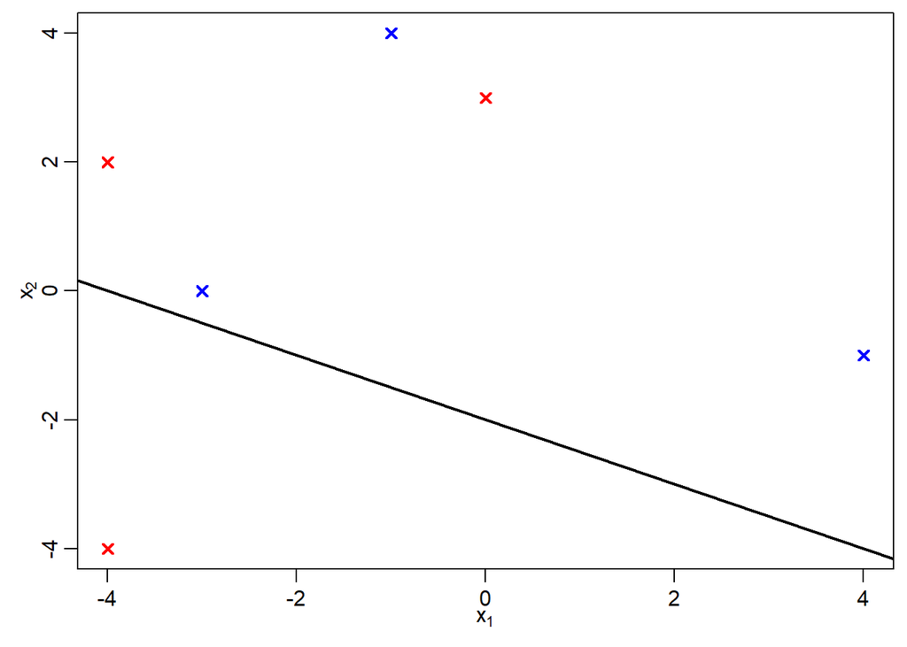

Wie die Zeichnung zeigt, trennt die Ebene die beiden Punktmengen nicht.

Click zum Öffnen, Click auf Inhalt zum Schließen.

## 7.2 Aufgabe

Gegebene sind mehrere Datenpunkte, und eine Hyper-Ebenengleichung.

1. Fertigen Sie eine Zeichnung zu dieser Hyperebene und den Datenpunkten an
2. Handelt es sich um eine trennende Hyperebene, wenn zwei Mengen von Datenpunkten betrachtet werden, jeweils die erste und zweite Hälfte der angegebenen Punkte?

Ebene: $\vec n^T \vec x +b=0$

mit $b=-2.5$ und $\vec n=$ $\begin{pmatrix} -1 \\ 2 \\ \end{pmatrix}$

und jeder Zeile der folgenden Matrix $P$ als ein Punkt, $P=$ $\begin{pmatrix} 3 & 3 \\ -1 & 2 \\ 0 & 2 \\ -3 & -3 \\ 0 & 1 \\ 3 & 2 \\ \end{pmatrix}$

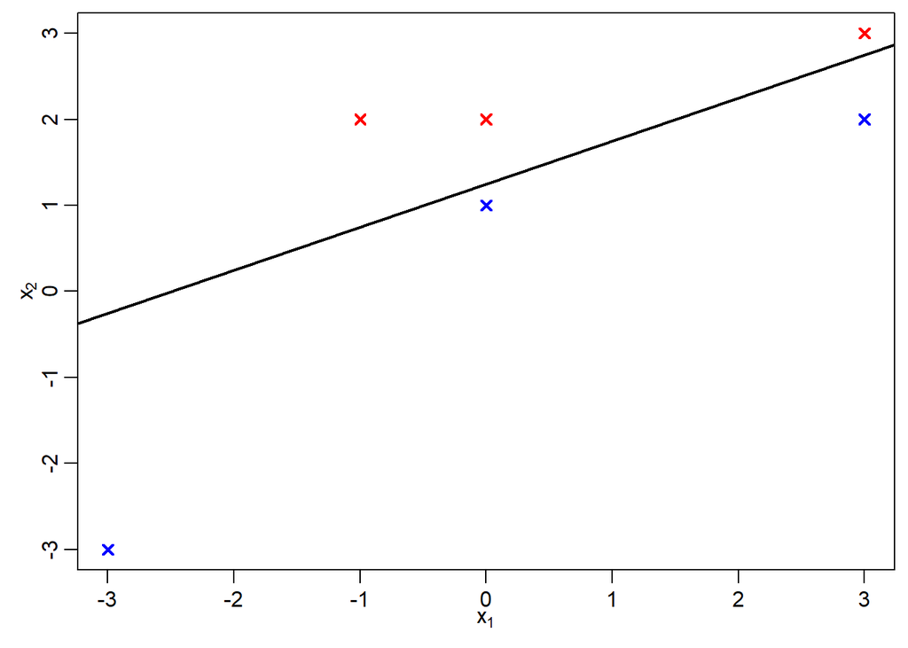

Wie die Zeichnung zeigt, trennt die Ebene die beiden Punktmengen exakt.

Click zum Öffnen, Click auf Inhalt zum Schließen.

## 7.3 Aufgabe

Gegebene sind mehrere Datenpunkte und eine Hyper-Ebenengleichung.

1. Bestimmen Sie, welche der Datenpunkte auf der gleichen Seite der Ebene liegen.
2. Bestimmen Sie den Abstand der Punkte zur Ebene

Ebene: $\vec n^T \vec x +b=0$

mit $b=2$ und $\vec n=$ $\begin{pmatrix} 2 \\ -4 \\ 2 \\ 1 \\ \end{pmatrix}$

und jeder Zeile der folgenden Matrix $P$ als ein Punkt, $P=$ $\begin{pmatrix} -4 & -3 & 4 & 4 \\ 0 & -4 & 0 & 4 \\ -4 & 3 & -1 & -1 \\ 4 & 2 & -3 & 0 \\ -1 & -1 & -2 & 0 \\ \end{pmatrix}$

Click zum Öffnen, Click auf Inhalt zum Schließen.

## 7.4 Aufgabe

Gegebene sind mehrere Datenpunkte und eine Hyper-Ebenengleichung.

1. Bestimmen Sie, welche der Datenpunkte auf der gleichen Seite der Ebene liegen.
2. Bestimmen Sie den Abstand der Punkte zur Ebene

Ebene: $\vec n^T \vec x +b=0$

mit $b=-1$ und $\vec n=$ $\begin{pmatrix} 1 \\ 0 \\ -1 \\ 0 \\ 1 \\ 0 \\ -1 \\ \end{pmatrix}$

und jeder Zeile der folgenden Matrix $P$ als ein Punkt, $P=$ $\begin{pmatrix} -2 & -2 & -1 & 1 & 1 & 0 & 0 \\ 2 & -1 & -1 & -2 & -1 & -2 & 1 \\ -2 & 1 & -2 & 2 & -1 & -2 & -2 \\ \end{pmatrix}$

Click zum Öffnen, Click auf Inhalt zum Schließen.

## 7.5 Aufgabe

Gegebene sind zwei Mengen von Datenpunkten und eine Hyper-Ebenengleichung.

Handelt es sich um eine trennende Hyperebene für diese Punkte?

Ebene: $\vec n^T \vec x +b=0$

mit $b=-1$ und $\vec n=$ $\begin{pmatrix} 1 \\ 0 \\ -1 \\ 0 \\ 1 \\ 0 \\ -1 \\ \end{pmatrix}$

Jede Zeile der folgenden Matrix $P_1$ ist ein Punkt in Menge 1, $P_1=$ $\begin{pmatrix} -2 & 0 & 1 & 2 & -2 & -1 & -2 \\ 0 & -2 & -2 & -2 & -1 & 2 & -2 \\ \end{pmatrix}$

und für Menge 2 $P_2=$ $\begin{pmatrix} -2 & 1 & 2 & -2 & 2 & 2 & -2 \\ 2 & 2 & -2 & -1 & 2 & -2 & 1 \\ \end{pmatrix}$

Click zum Öffnen, Click auf Inhalt zum Schließen.

## 7.6 Aufgabe

Gegebene sind mehrere Datenpunkte. Geben Sie die Koordinatengleichung für eine Hyperebene an, die diese Punkte exakt in die erste und zweite Hälfte trennt.

Tipp: Mehrere Lösungen sind möglich. Eine Zeichnung der Punkte hilft.

Jede Zeile der folgenden Matrix $P$ ist ein Punkt, $P=$ $\begin{pmatrix} 3 & 4 \\ -3 & 2 \\ -2 & 1 \\ 2 & 0 \\ 4 & 2 \\ 0 & 0 \\ \end{pmatrix}$

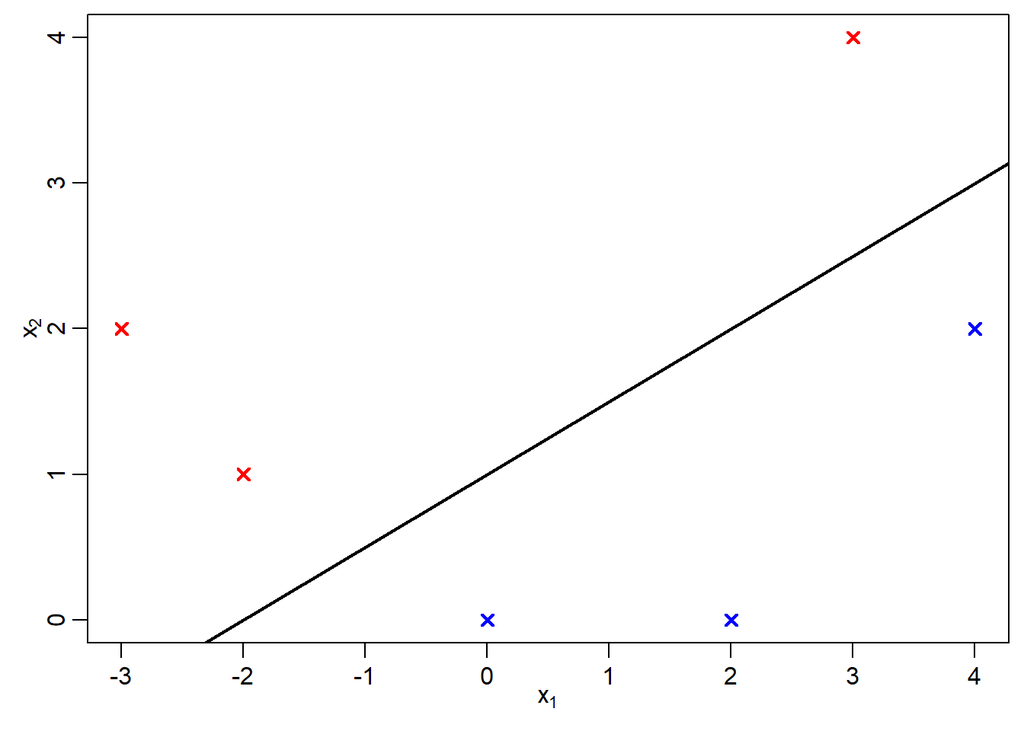

Gerade: $\vec n^T \vec x +b=0$ mit $b=-2$ und $\vec n=$$\begin{pmatrix} -1 \\ 2 \\ \end{pmatrix}$
Wie die Zeichnung zeigt, trennt die Hyperebene (bzw. Gerade) die beiden Punktmengen.

Click zum Öffnen, Click auf Inhalt zum Schließen.

## 7.7 Aufgabe

Gegebene sind mehrere Datenpunkte. Geben Sie die Koordinatengleichung für eine Hyperebene an, die diese Punkte exakt in die erste und zweite Hälfte trennt.

Tipp: Mehrere Lösungen sind möglich. Eine Zeichnung der Punkte hilft.

Jede Zeile der folgenden Matrix $P$ ist ein Punkt, $P=$ $\begin{pmatrix} -1 & -2 \\ 4 & -3 \\ 2 & -2 \\ 3 & 3 \\ 1 & 0 \\ 2 & 0 \\ \end{pmatrix}$

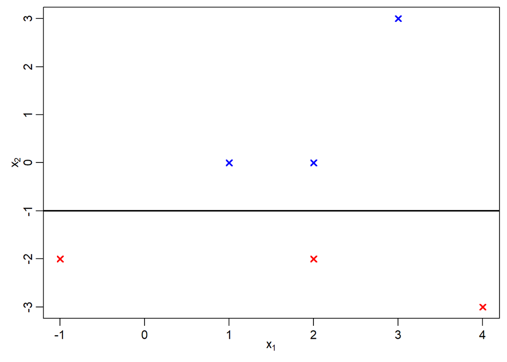

Gerade: $\vec n^T \vec x +b=0$ mit $b=1$ und $\vec n=$$\begin{pmatrix} 0 \\ 1 \\ \end{pmatrix}$
Wie die Zeichnung zeigt, trennt die Hyperebene (bzw. Gerade) die beiden Punktmengen.

Click zum Öffnen, Click auf Inhalt zum Schließen.

## 7.8 Aufgabe

Gegeben sei folgende trennende Hyperebene und zwei Mengen von Datenpunkte.

Bestimmen Sie das ‘Margin’ $M$ und welche Punkte ‘auf’ diesem Margin liegen, also den kleinsten Abstand zur Hyperebene haben.

E: $\vec n^T \vec x +b=0$ mit $b=-4$ und $\vec n=$ $\begin{pmatrix} 2 \\ -1 \\ \end{pmatrix}$

Für Punktmenge 1 sind die Koordinaten $P_1=$ $\begin{pmatrix} 4 & -1 \\ 4 & 1 \\ 3 & -2 \\ \end{pmatrix}$

Für Punktmenge 2 sind die Koordinaten $P_2=$ $\begin{pmatrix} -4 & -1 \\ 0 & 2 \\ -1 & -3 \\ \end{pmatrix}$

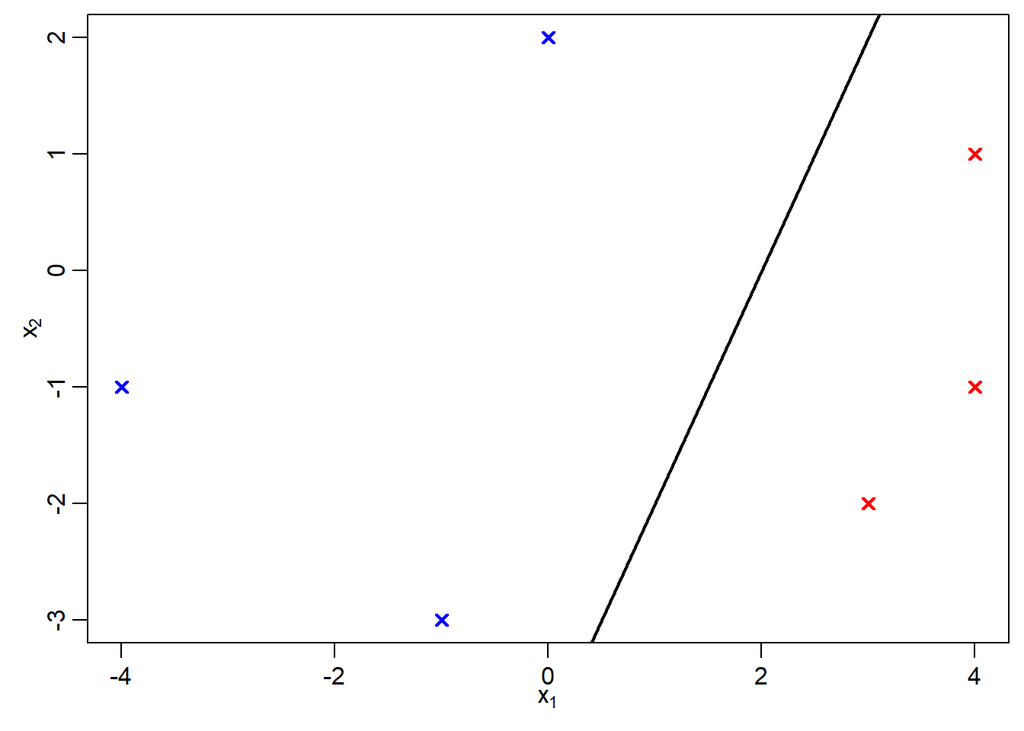

Margin ist der kleinste Abstand einer der gegebenen Punkte zur Ebene.  
Für die Abstandsformel müssen erst $b$ und $\vec n$ normalisiert werden, also durch Länge von $\vec n$ teilen.  
$|\vec n|=\sqrt{2^2 + (-1)^2}=\sqrt{5}$. Somit $b_n=-4 / \sqrt{5}$ und $\vec n_n= \pmatrix{2/\sqrt{5} \\ -1/\sqrt{5}}$. Im folgenden meint $\vec b_n$ einen Vektor dessen Elemente alle $b_n$ sind.  
Abstände bestimmen mit $|P_1 \vec n_n + \vec b|$ und Abstände bestimmen mit $|P_2 \vec n_n + \vec b|$.  
Liefert $M=3/\sqrt{5}$, wobei jeweils ein Punkt aus beiden Mengen (zweiter aus erster Menge, dritter aus zweiter Menge) diesen Abstand aufweisen (also auf dem Margin liegt).

Click zum Öffnen, Click auf Inhalt zum Schließen.

## 7.9 Aufgabe

Gegeben sei folgende trennende Hyperebene und zwei Mengen von Datenpunkte.

Bestimmen Sie das ‘Margin’ $M$ und welche Punkte ‘auf’ diesem Margin liegen, also den kleinsten Abstand zur Hyperebene haben.

E: $\vec n^T \vec x +b=0$ mit $b=-4$ und $\vec n=$ $\begin{pmatrix} -1 \\ 1 \\ -1 \\ 1 \\ \end{pmatrix}$

Für Punktmenge 1 sind die Koordinaten $P_1=$ $\begin{pmatrix} -4 & -1 & -4 & -1 \\ 0 & 2 & 0 & 2 \\ \end{pmatrix}$

Für Punktmenge 2 sind die Koordinaten $P_2=$ $\begin{pmatrix} 4 & -1 & 4 & -1 \\ 4 & 1 & 4 & 1 \\ 3 & -2 & 3 & -2 \\ -1 & -3 & -1 & -3 \\ \end{pmatrix}$

Click zum Öffnen, Click auf Inhalt zum Schließen.

# 8 Finite Differenzen

## 8.1 Aufgabe

Zeigen Sie, dass die Matrix $T_n$ für beliebige $n$ invertierbar ist. Zeigen Sie auch, dass die Matrix $T_n$ positiv definit ist.

Als Erinnerung ein Beispiel für $n=5$:

$$T_5 =
\left[
\begin{array}{rrrrr}
1 & -1 & 0 & 0 &0\\
-1 & 2 & -1 & 0& 0 \\
0 & -1 & 2 & -1& 0\\
0& 0 & -1 & 2& -1\\
0&0& 0 & -1 & 2\\
\end{array}
\right]$$

Click zum Öffnen, Click auf Inhalt zum Schließen.

## 8.2 Aufgabe

Welche zentrale Eigenschaft der Eigenvektoren der Matrix $C$ können Sie ohne Berechnung der Eigenvektoren oder Eigenwerte bereits angeben?

Als Erinnerung ein Beispiel für $n=5$:

$$C_5 =
\left[
\begin{array}{rrrrr}
2 & -1 & 0 & 0 &-1 \\
-1 & 2 & -1 & 0& 0 \\
0 & -1 & 2 & -1& 0\\
0& 0 & -1 & 2& -1\\
-1 &0& 0 & -1 & 2\\
\end{array}
\right]$$

Click zum Öffnen, Click auf Inhalt zum Schließen.

## 8.3 Aufgabe

Bestimmen Sie die Inverse von $T_3$ und $T_4$. Raten Sie, wie die Inverse von $T_5$ aussieht. Prüfen Sie dann, ob die geratene Inverse richtig ist.

Hinweis:

$T_3=$$\begin{pmatrix} 1 & -1 & 0 \\ -1 & 2 & -1 \\ 0 & -1 & 2 \\ \end{pmatrix}$
$T_4=$$\begin{pmatrix} 1 & -1 & 0 & 0 \\ -1 & 2 & -1 & 0 \\ 0 & -1 & 2 & -1 \\ 0 & 0 & -1 & 2 \\ \end{pmatrix}$
$T_5=$$\begin{pmatrix} 1 & -1 & 0 & 0 & 0 \\ -1 & 2 & -1 & 0 & 0 \\ 0 & -1 & 2 & -1 & 0 \\ 0 & 0 & -1 & 2 & -1 \\ 0 & 0 & 0 & -1 & 2 \\ \end{pmatrix}$

Click zum Öffnen, Click auf Inhalt zum Schließen.

## 8.4 Aufgabe

Berechnen Sie die $LL^T$ bzw. Cholesky Zerlegung von $T_3$ und $T4$. Raten Sie, wie die Zerlegung von von $T_5$ aussieht. Prüfen Sie dann, ob die geratene Zerlegung richtig ist.

Click zum Öffnen, Click auf Inhalt zum Schließen.

## 8.5 Aufgabe

Gegeben Sei das LGS $B \vec u=\vec f$, mit

$$\vec f=\pmatrix{-2\\1\\3\\-2}$$

Für diese spezielle Matrix $B$, warum lässt sich hier bereits an $\vec f$ ablesen, dass das LGS lösbar ist (d.h., Lösungsmenge ist nicht leer)?

Bestimmen Sie die Lösungsmenge.

Lösung Teil 1:

Click zum Öffnen, Click auf Inhalt zum Schließen.

Lösung Teil 2:

Click zum Öffnen, Click auf Inhalt zum Schließen.

## 8.6 Aufgabe

Unter Berücksichtigung der vorigen Aufgabe, was ist immer über die Lösungsmenge des LGS $B\vec u=\vec f$ bekannt (unabhängig von Dimension $n \times n$ der Matrix $B$ und unabhängig von den Werten $\vec f$), vorausgesetzt, dass diese Lösungsmenge nicht leer ist?

Click zum Öffnen, Click auf Inhalt zum Schließen.

## 8.7 Aufgabe

Konstruieren Sie ein Beispiel in einer Zeichnung, wobei die Vorwärtsdifferenz eine schlechtere Annäherung liefert als die Rückwärtsdifferenz, trotz gleicher Schrittweite $h$.

(Erinnerung: Die Fehlerschätzung dieser beiden Ansätze ist zwar gleich, Fehler aus einem konkreten Beispiel können sich aber unterscheiden.)

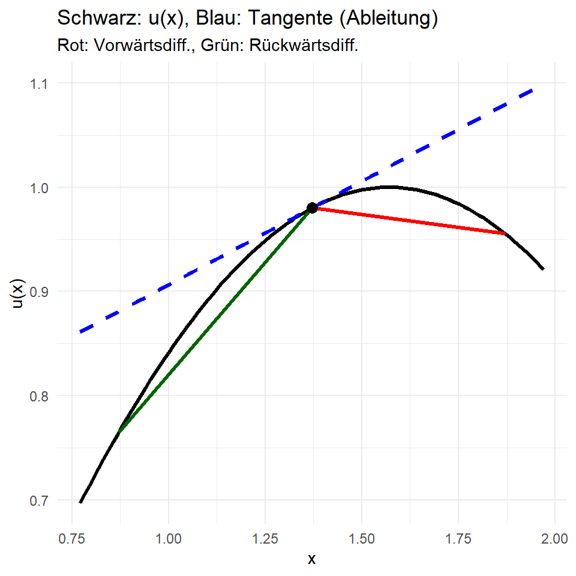

Click zum Öffnen, Click auf Inhalt zum Schließen.

## 8.8 Aufgabe

Konstruieren Sie ein Beispiel in einer Zeichnung, wobei die Zentraldifferenz einen deutlich positiven Wert (für die Annäherung der Steigung) liefert, obwohl die tatsächliche Steigung 0 ist.

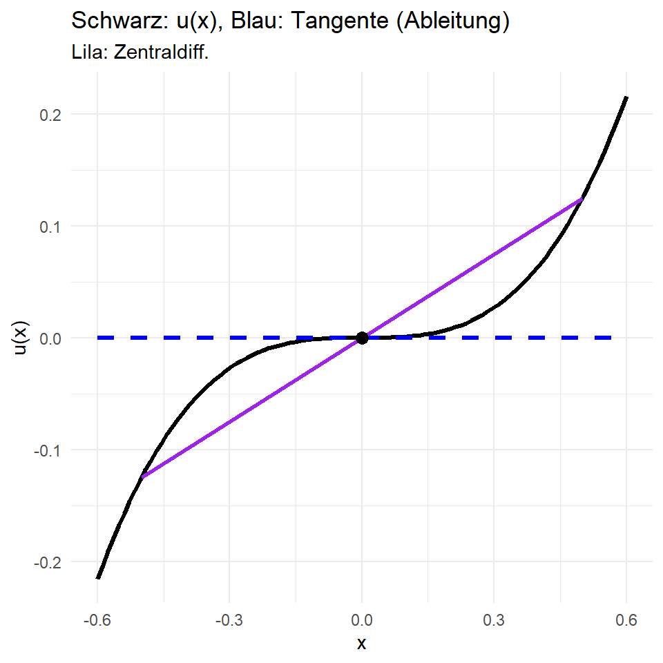

Click zum Öffnen, Click auf Inhalt zum Schließen.

## 8.9 Aufgabe

Welche Art von Differenz wird in der folgenden Zeichnung in rot dargestellt?

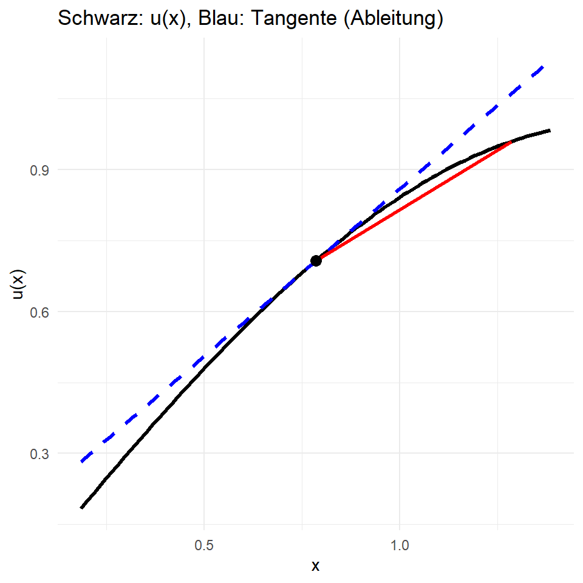

Click zum Öffnen, Click auf Inhalt zum Schließen.

## 8.10 Aufgabe

Bestimmen Sie mittels finiter Differenz die Lösung $u(x)$ im Intervall $[0,10]$ für $-\frac{d^2u}{dx^2}=1$.

Beachten Sie hierfür:

- Randwerte: $u(0)=0$, $u(10)=0$
- Schrittweite $h=2$

Fertigen Sie eine Zeichnung der Lösung an.

Wenn Sie einen Vergleich zur Überprüfung benötigen:

- Die analytische Lösung ist $u(x)=\frac{-(x^2-10*x)}{2}$

Schrittweite von 2 im Interval von 0 bis 10 erfordert 4 Schritte (also $4 \times 4$ Matrix).
$$(K/h^2) \vec u =\vec f \rightarrow
\frac{1}{2^2}
\left[\begin{array}{rrrrrrrrr}
2 & -1 & & \\
-1 & 2 & -1 & \\
& -1 & 2 & -1 \\
& & -1 & 2 \\
\end{array}\right]
\left[\begin{array}{r}
u_1 \\
u_2 \\
u_3 \\
u_4 \\
\end{array}\right]
=
\left[\begin{array}{r}
1 \\
1 \\
1 \\
1 \\
\end{array}\right]$$
Die Inverse von $K/h^2$ ist $(K/h^2)^{-1}=$$\begin{pmatrix} 3.2 & 2.4 & 1.6 & 0.8 \\ 2.4 & 4.8 & 3.2 & 1.6 \\ 1.6 & 3.2 & 4.8 & 2.4 \\ 0.8 & 1.6 & 2.4 & 3.2 \\ \end{pmatrix}$
Multiplikation liefert $\vec u = (K/h^2)^{-1} \vec f=$$\begin{pmatrix} 8 \\ 12 \\ 12 \\ 8 \\ \end{pmatrix}$

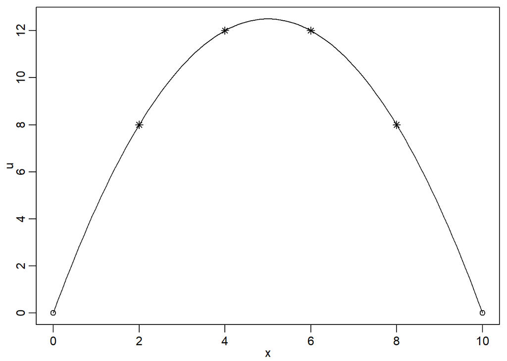

Click zum Öffnen, Click auf Inhalt zum Schließen.

## 8.11 Aufgabe

Wenn die bekannte Matrix $K$ die zweite Ableitung liefert (diskretisiert, über Vorwärts-Rückwärts-Differenz). Welche ähnlich Matrix liefert dann die erste Ableitung über die Zentraldifferenz?

Prüfen Sie ihr Lösung an einem Beispiel. (d.h., Ableitung einer diskretisierten Funktion mit bekannter erster Ableitung)

Click zum Öffnen, Click auf Inhalt zum Schließen.